# Регрессионный анализ для бинарных данных

## Линейные модели на R, осень 2014

Вадим Хайтов  
Каф. Зоологии беспозвоночных, СПбГУ

# Мы рассмотрим

- Регрессионный анализ для бинарных зависимых переменных
- Некторые положения теории обобщенных линейных моделей (Generalized linear models)

# Вы сможете

- Объяснить, что такое метод максимального правдоподобия
- Построить логистическую регрессионную модель
- Дать трактовку параметрам логистической регрессионной модели
- Провести анализ девиансы, основанный на логистичской регрессии

# Бинарные данные - очень распространенный тип зависимых переменных

- Вид есть - вида нет
- Кто-то в результате эксперимента выжил или умер
- Пойманное животное заражено паразитами или здорово
- Команда выиграла или проиграла

и т.д.

Для моделирования таких данных метод наименьших квадратов не годится

# На каком острове лучше искать ящериц?

Пример взят из книги Quinn & Keugh (2002)

Оригинальная работа Polis et al. (1998)

```r
liz <- read.csv("polis.csv")
head(liz)
```

```
##     X.ISLAND PARATIO UTA PA PREDICT
## 1       Bota   15.41   P  1  0.5554
## 2     Cabeza    5.63   P  1  0.9145
## 3    Cerraja   25.92   P  1  0.1106
## 4 Coronadito   15.17   A  0  0.5684
## 5     Flecha   13.04   P  1  0.6777
## 6   Gemelose   18.85   A  0  0.3699
```

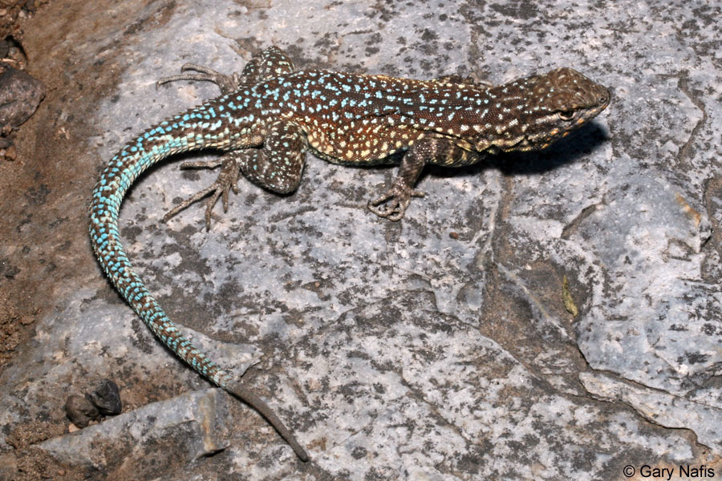

# Зависит ли встречаемость ящериц от характеристик острова?

Обычную линейную регрессию можно подобрать...

```r
fit <- lm(PA ~ PARATIO, data = liz)
summary(fit)
```

```
##
## Call:
## lm(formula = PA ~ PARATIO, data = liz)
##
## Residuals:
##    Min     1Q Median     3Q    Max
## -0.649 -0.445  0.178  0.264  0.605
##
## Coefficients:
##             Estimate Std. Error t value Pr(>|t|)
## (Intercept)  0.86881    0.14088    6.17  0.00001 ***
## PARATIO     -0.01828    0.00557   -3.28   0.0044 **
## ---
## Signif. codes:  0 '***' 0.001 '**' 0.01 '*' 0.05 '.' 0.1 ' ' 1
##
## Residual standard error: 0.413 on 17 degrees of freedom
## Multiple R-squared:  0.388,  Adjusted R-squared:  0.352
## F-statistic: 10.8 on 1 and 17 DF,  p-value: 0.00438
```

она категорически не годится

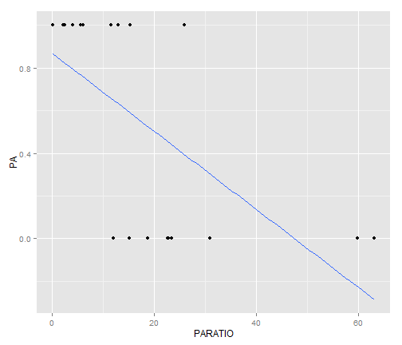

# Эти данные лучше описывает логистическая кривая

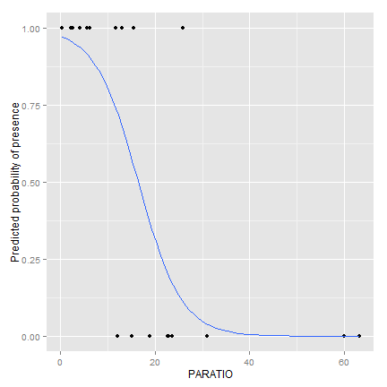

Эта кривая описывается такой формулой

\[ \pi(x) = \frac{e^{\beta_0+\beta_1x}}{1+e^{\beta_0+\beta_1x}} \]

# Зависимую величину можно представить несколькими способами

- 1. Дискретный результат: 1 или 0
- 2. Вероятность: \(\pi = \frac{N_1}{N_{total}}\) варьирует от 0 до 1
- 3. Шансы (odds): \(g=\frac{\pi}{1-\pi}\) варьируют от 0 до \(+\infty\)

# Вероятность и шанс

Вероятность – это отношение, выражающее то, насколько возможно данное событие по отношению к другим исходам.

Шансы - это отношение того, что событие произойдет, к тому, что оно не произойдет.

- Логиты (logit): \(\ln(g)=\ln(\frac{\pi}{1-\pi})\) варьируют от \(-\infty\) до \(+\infty\)

# Логистическая модель после логит-перобразования становится линейной

\[ g(x)=\ln(\frac{\pi(x)}{1-\pi(x)})=\beta_0 + \beta_1x\]

# Для подбора параметров уравнения применяется метод максимального правдоподобия

\[ g(x)=\ln(\frac{\pi(x)}{1-\pi(x)})=\beta_0 + \beta_1x\]

## Метод максимального правдоподбия применяется для тех случаев, когда распределение остатков не может быть описано нормальным распеделением

В результате итерационных проедур происходит подбор таких коэффициентов, при которых вероятность получения имеющегося у нас набора данных оказывается максимальной.

# В основе метода максимального лежит вычисление функции правдоподобия

\[ Lik(\beta_0, \beta_1) = \Pi L_i\]

Удобнее работать с логарифмом функции максимльного правдоподобия - \(logLik\)

# Функция максимального правдоподобия оценивает вероятность получения наших данных при условии страведливости данной модели

# Подберем модель с помощью функции `glm()`

```r
liz_model <- glm(PA ~ PARATIO , family="binomial", data = liz)
summary(liz_model)
```

```
##
## Call:
## glm(formula = PA ~ PARATIO, family = "binomial", data = liz)
##
## Deviance Residuals:
##    Min      1Q  Median      3Q     Max
## -1.607  -0.638   0.237   0.433   2.099
##
## Coefficients:
##             Estimate Std. Error z value Pr(>|z|)
## (Intercept)    3.606      1.695    2.13    0.033 *
## PARATIO       -0.220      0.101   -2.18    0.029 *
## ---
## Signif. codes:  0 '***' 0.001 '**' 0.01 '*' 0.05 '.' 0.1 ' ' 1
##
## (Dispersion parameter for binomial family taken to be 1)
##
##     Null deviance: 26.287  on 18  degrees of freedom
## Residual deviance: 14.221  on 17  degrees of freedom
## AIC: 18.22
##
## Number of Fisher Scoring iterations: 6
```

# В результатах появились новые термины:

`z value`  
`Null deviance`  
`Residual deviance`  
`AIC`и

# z value

Это величина критерия Вальда (Wald statistic) - аналог t-критерия

Используется для проверки \(H_0: \beta_1=0\)

\[z=\frac{b_1}{SE_{b_1}}\]

Сравнивают со стандартизованным нормальным распределением (z-рспределение)

Дает надежные оценки p-value при больших выборках

# Более надежные результаты дает тест отношения правдоподобий (Likelihood ratio test)

\[ LR = 2\ln(\frac{Lik_l}{Lik_s}) = 2(logLik_l - logLik_s)\]

# Null deviance и Residual deviance

- *"Насыщенная" модель* - модель, подразумевающая, что каждая из n точек имеет свой собственный параметр, следовательно надо подобрать n параметров. Вероятность существования данных для такой модели равна 1. \(logLik_{satur}= ln(1) = 0\)
- *"Нулевая" модель* - модель подразумевающая, что для описания всех точек надо подобрать только 1 параметр. Эта модель включает только свободный член \(g(x) = \beta_0\). У этой модели есть значение \(logLik_{nul}\)
- *"Предложенная" модель* - модель, подобранная в нашем анализе \(g(x) = \beta_0 + \beta_1x\) для нее есть \(logLik_{prop}\)

# Null deviance и Residual deviance

### Девианса - это оценка отклонения логарифма максимального правдоподобия одной модели от логарифма максимального правдоподобия другой модели.

Остаточная девианса: \(2(logLik_{satur} - logLik_{prop})=-2logLik_{prop}\)  
Нулевая девианса: \(2(logLik_{satur} - logLik_{nul})=-2logLik_{nul}\)

Проверим

```r
(Dev_resid <- -2*as.numeric(logLik(liz_model))) #Остаточная девианса
```

```
## [1] 14.22
```

```r
(Dev_nul <- -2*as.numeric(logLik(update(liz_model, ~-PARATIO)))) #Нулевая девианса
```

```
## [1] 26.29
```

# По соотношению нулевой девиансы и остаточной девиансы можно понять насколько хороша модель

\[ G^2 = -2(logLik_{nul} - logLik_{prop})\]

```r
(G2 <- Dev_nul - Dev_resid)
```

```
## [1] 12.07
```

- \(G^2\) - это девианса полной и редуцированной модели
- \(G^2\) - аналог \(SS_{residuals}\) в обычном регрессионном анализе
- \(G^2\) - подчиняется \(\chi^2\) распределению (с параметом df = 1) если нулевая модель и предложенная модель не отличаются друг от друга.
- \(G^2\) можно использовать для проверки нулевой гипотезы \(H_0: \beta_1=0\)

# Анализ девиансы

Это аналог дисперсионного анализа для сравния полной и редуцированной модели

```r
anova(liz_model, test="Chi")
```

```
## Analysis of Deviance Table
##
## Model: binomial, link: logit
##
## Response: PA
##
## Terms added sequentially (first to last)
##
##
##         Df Deviance Resid. Df Resid. Dev Pr(>Chi)
## NULL                       18       26.3
## PARATIO  1     12.1        17       14.2  0.00051 ***
## ---
## Signif. codes:  0 '***' 0.001 '**' 0.01 '*' 0.05 '.' 0.1 ' ' 1
```

# AIC - Информационный критерий Акаике (Akaike Information Criterion)

\[ AIC = - 2logLik_{prop} + 2p\]

где \(logLik_{prop}\) - логарифм функции правдоподобия для предложенной модели  
\(2p\) - штраф за введение в модель \(p\) параметров

# Задание

Расчитайте вручную критерий Акаике для нашей модели

# Решение

```r
(2*2 - 2*as.numeric(logLik(liz_model)))
```

```
## [1] 18.22
```

```r
#или

AIC(liz_model)
```

```
## [1] 18.22
```

# Как трактовать коэффициенты подобранной модели?

\[ g(x)=\ln(\frac{\pi(x)}{1-\pi(x)})=\beta_0 + \beta_1x\]

```r
coef(liz_model)
```

```
## (Intercept)     PARATIO
##      3.6061     -0.2196
```

- \(\beta_0\) - не имеет особого смысла, просто поправочный коэффициент
- \(\beta_1\) - *на сколько* единиц изменяется *логарифм* величины шансов (odds) при изменении на одну единицу значения предиктора  
  Тратктовать такую величину неудобно и трудно. Хотя по знаку \(\beta_1\) можно сазу понять возрастает ли вероятность или снижается.

# Немного алгебры...

посмотрим как изменится \(g(x)=\ln(\frac{\pi(x)}{1-\pi(x)})\) при изменении предиктора на 1

\[g(x+1) - g(x) = ln(odds_{x+1}) - ln(odds_x) = ln(\frac{odds_{x+1}}{odds_x})\]

> -Задание: завершите алгебраическое преобразование

# Решение

\[ln(\frac{odds_{x+1}}{odds_x}) = \beta_0 + \beta_1(x+1) - \beta_0 - \beta_1x = \beta_1\]

\[ln(\frac{odds_{x+1}}{odds_x}) = \beta_1\]

\[\frac{odds_{x+1}}{odds_x} = e^{\beta_1}\]

# Полученная величина имеет определенный смысл и называтся отношением шансов (odds ratio)

```r
exp(coef(liz_model)[2])
```

```
## PARATIO
##  0.8029
```

Отношение шансов (odds ratio) показывает *во сколько* раз изменяется отношение шансов встретить ящерицу при увеличении отношения периметра острова к его площади на одну единицу

Отношение шансов изменяется в 0.8029 раза. То есть, чем меньше остров, тем меньше шансов встретить ящерицу

# Подобранные коэффициенты позволяют построить логистическую кривую

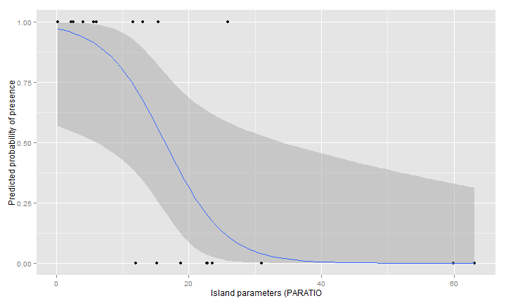

Эта кривая описывается такой формулой

\[ \pi(x) = \frac{e^{\beta_0+\beta_1x}}{1+e^{\beta_0+\beta_1x}} \]

Кривая имеет доверительный интервал (серая область)

# Задание: Найдите границы 95% доверительного интервала для параметров построенной модели и для отношения шансов

# Решение

Доверительные интервалы для коэффициентов:

```r
confint(liz_model) # для логитов
```

```
##               2.5 %   97.5 %
## (Intercept)  1.0059  8.04214
## PARATIO     -0.4849 -0.06649
```

```r
exp(confint(liz_model)) # для отношения шансов
```

```
##              2.5 %    97.5 %
## (Intercept) 2.7345 3109.2748
## PARATIO     0.6157    0.9357
```

# Множественная логистическая регрессия

# От чего зависит уровень смертности пациентов, выписанных из реанимации?

Данные, полученные на основе изучения 200 историй болезни пациентов одного из американских госпиталей  
`STA`: Статус (0 = Выжил, 1 = умер)  
`AGE`: Возраст  
`SEX`: Пол  
`RACE`: Раса  
`SER`: Тип мероприятий в реанимации (Medical, 1 = Surgical)  
`CAN`: Присутствует ли онкология? (No,Yes)  
`CRN`: Присутсвует ли почечная недостаточность (No, Yes)  
`INF`: Наличие инфекции при госпитализации (No, Yes)  
`CPR`: Была ли сердечно-легочная реанимация (No, Yes)  
`SYS`: Давление (in mm Hg)

`HRA`: ЧСС (beats/min)  
`PRE`: Были ли случаи реанимации ранее (0 = No, 1 = Yes)  
`TYP`: Тип госпитализации (Elective, Emergency)  
`FRA`: Есть ли случаи переломов костей (No, Yes)  
`PO2`: Концентрация кислорода в крови (1 = >60, 2 = 60)  
`PH`: PH from initial blood gases (1 = 7.25, 2 <7.25) `PCO`: Концентрация углекислого газа в крови (1 = 45, 2 = >45)  
`BIC`: Bicarbonate from initial blood gases (1 = 18, 2 = <18) `CRE`: Концентрация кретинина в крови (1 = 2.0, 2 = >2.0)  
`LOC`: Был ли пациент в сознании при госпитализации (1 = no coma or stupor, 2= deep stupor, 3 = coma)

# Смотрим на данные

```r
surviv <- read.table("ICU.csv", header=TRUE, sep=";")
head(surviv)
```

```
##   STA AGE    SEX   RAC      SER CAN CRN INF CPR SYS HRA PRE       TYP FRA PO2 PH PCO BIC
## 1   0  27 Female White  Medical  No  No Yes  No 142  88  No Emergency  No   1  1   1   1
## 2   0  59   Male White  Medical  No  No  No  No 112  80 Yes Emergency  No   1  1   1   1
## 3   0  77   Male White Surgical  No  No  No  No 100  70  No  Elective  No   1  1   1   1
## 4   0  54   Male White  Medical  No  No Yes  No 142 103  No Emergency Yes   1  1   1   1
## 5   0  87 Female White Surgical  No  No Yes  No 110 154 Yes Emergency  No   1  1   1   1
## 6   0  69   Male White  Medical  No  No Yes  No 110 132  No Emergency  No   2  1   1   2
##   CRE LOC
## 1   1   1
## 2   1   1
## 3   1   1
## 4   1   1
## 5   1   1
## 6   1   1
```

# Строим модель

```r
surv_model <- glm(STA ~ . , family = "binomial", data = surviv)
summary(surv_model)
```

```
##
## Call:
## glm(formula = STA ~ ., family = "binomial", data = surviv)
##
## Deviance Residuals:
##    Min      1Q  Median      3Q     Max
## -1.805  -0.603  -0.235  -0.118   2.870
##
## Coefficients:
##              Estimate Std. Error z value Pr(>|z|)
## (Intercept)  -8.35382    2.88759   -2.89  0.00382 **
## AGE           0.05110    0.01717    2.98  0.00292 **
## SEXMale       0.55306    0.50158    1.10  0.27019
## RACOther      1.21408    1.53381    0.79  0.42862
## RACWhite      0.80676    1.16724    0.69  0.48946
## SERSurgical  -0.63886    0.59225   -1.08  0.28073
## CANYes        2.75033    0.97762    2.81  0.00490 **
## CRNYes       -0.11002    0.77638   -0.14  0.88731
## INFYes       -0.07443    0.53292   -0.14  0.88892
## CPRYes        0.93338    0.99234    0.94  0.34692
## SYS          -0.01089    0.00798   -1.37  0.17202
## HRA          -0.00254    0.00951   -0.27  0.78941
## PREYes        0.97765    0.63549    1.54  0.12395
## TYPEmergency  2.67401    0.99546    2.69  0.00723 **
## FRAYes        1.25685    1.00964    1.24  0.21318
## PO2           0.27541    0.85580    0.32  0.74759
## PH            2.37703    1.23187    1.93  0.05365 .
## PCO          -3.14692    1.37961   -2.28  0.02255 *
## BIC          -0.76518    0.91314   -0.84  0.40205
## CRE           0.14024    1.07119    0.13  0.89584
## LOC           2.72308    0.76014    3.58  0.00034 ***
## ---
## Signif. codes:  0 '***' 0.001 '**' 0.01 '*' 0.05 '.' 0.1 ' ' 1
##
## (Dispersion parameter for binomial family taken to be 1)
##
##     Null deviance: 200.16  on 199  degrees of freedom
## Residual deviance: 128.85  on 179  degrees of freedom
## AIC: 170.9
##
## Number of Fisher Scoring iterations: 6
```

# Проведем анализ девиансы

```r
anova(surv_model, test="Chi")
```

```
## Analysis of Deviance Table
##
## Model: binomial, link: logit
##
## Response: STA
##
## Terms added sequentially (first to last)
##
##
##      Df Deviance Resid. Df Resid. Dev  Pr(>Chi)
## NULL                   199        200
## AGE   1     7.85       198        192   0.00507 **
## SEX   1     0.00       197        192   0.97572
## RAC   2     1.26       195        191   0.53364
## SER   1     8.32       194        183   0.00392 **
## CAN   1     0.72       193        182   0.39726
## CRN   1     2.62       192        179   0.10559
## INF   1     2.03       191        177   0.15391
## CPR   1     3.92       190        173   0.04777 *
## SYS   1     5.65       189        168   0.01741 *
## HRA   1     0.79       188        167   0.37537
## PRE   1     0.91       187        166   0.33955
## TYP   1    12.79       186        153   0.00035 ***
## FRA   1     0.48       185        153   0.48914
## PO2   1     0.03       184        153   0.87152
## PH    1     0.02       183        153   0.90183
## PCO   1     1.31       182        152   0.25312
## BIC   1     0.07       181        151   0.78999
## CRE   1     0.23       180        151   0.63282
## LOC   1    22.32       179        129 0.0000023 ***
## ---
## Signif. codes:  0 '***' 0.001 '**' 0.01 '*' 0.05 '.' 0.1 ' ' 1
```

# Строим сокращенную модель

```r
surv_model_reduced <- glm(STA ~ AGE + TYP + PH + PCO + LOC, family = "binomial", data = surviv)

anova(surv_model, surv_model_reduced, test = "Chi")
```

```
## Analysis of Deviance Table
##
## Model 1: STA ~ AGE + SEX + RAC + SER + CAN + CRN + INF + CPR + SYS + HRA +
##     PRE + TYP + FRA + PO2 + PH + PCO + BIC + CRE + LOC
## Model 2: STA ~ AGE + TYP + PH + PCO + LOC
##   Resid. Df Resid. Dev  Df Deviance Pr(>Chi)
## 1       179        129
## 2       194        145 -15    -16.6     0.35
```

# Посмотримм на AIC полной и сокращенной моделей

```r
AIC(surv_model, surv_model_reduced)
```

```
##                    df   AIC
## surv_model         21 170.9
## surv_model_reduced  6 157.4
```

Предпочтение отдается той модели, у которой AIC меньше

```r
summary(surv_model_reduced)
```

```
##
## Call:
## glm(formula = STA ~ AGE + TYP + PH + PCO + LOC, family = "binomial",
##     data = surviv)
##
## Deviance Residuals:
##    Min      1Q  Median      3Q     Max
## -2.086  -0.657  -0.331  -0.194   2.461
##
## Coefficients:
##              Estimate Std. Error z value   Pr(>|z|)
## (Intercept)   -7.5883     1.5010   -5.06 0.00000043 ***
## AGE            0.0362     0.0124    2.93     0.0034 **
## TYPEmergency   2.1275     0.7722    2.76     0.0059 **
## PH             1.6480     0.8403    1.96     0.0499 *
## PCO           -1.9096     0.9702   -1.97     0.0490 *
## LOC            2.1545     0.5478    3.93 0.00008379 ***
## ---
## Signif. codes:  0 '***' 0.001 '**' 0.01 '*' 0.05 '.' 0.1 ' ' 1
##
## (Dispersion parameter for binomial family taken to be 1)
##
##     Null deviance: 200.16  on 199  degrees of freedom
## Residual deviance: 145.43  on 194  degrees of freedom
## AIC: 157.4
##
## Number of Fisher Scoring iterations: 6
```

# Вопрос: Во сколько раз изменяется отношение шансов при условии, что пациента госпитализировали в экстренном порядке?

Hint: Вам понадобится переменная `TYP`

# Решение

```r
exp(coef(surv_model_reduced)[3])
```

```
## TYPEmergency
##        8.393
```

# Как изменяется вероятность смерти после реанимации в зависимости от возраста?

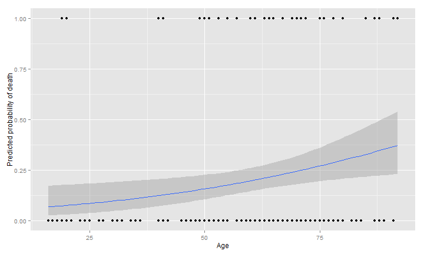

# Summary

- Для моделирования бинарных данных применяется логистическая регрессия
- Оценка коэффициентов логистической регресси производится методом максимального правдоподобия
- Для проверки нулевой гипотезы о наличии зависимости применяют тест отношений правдоподобия

# Что почитать

- Кабаков Р.И. R в действии. Анализ и визуализация данных на языке R. М.: ДМК Пресс, 2014.
- Quinn G.P., Keough M.J. (2002) Experimental design and data analysis for biologists, pp. 359- 371